# Problem Set 1 QM

Andriy Levitskyy

# Question 3

The question asks to compare non-durable goods and services expenditure from 2 datasets: CES- Consumer expenditure survey and NIPA- National Income and Product accounts. I did years 2009-2013 instead of 2007-2011 as in the task, because NIPA data starts from 2009.

Downloading CES dataset:

```r
#knitr and pander library will be used to make ouptut look a bit better
library(knitr)
library(pander)
setwd("/Users/andriylevitskyy/Desktop/MA/Qu Macro/Problem Set1")
for(i in c("07","08","09","10","11","12","13")){
  setwd(paste("/Users/andriylevitskyy/Desktop/MA/Qu Macro/Problem Set1/",
paste("intrvw",i,sep=""),"/",paste("intrvw",i,sep=""),sep=""))
  print(paste("intrvw",i,sep=""))
  for(z in c("1x","2","3","4")){
    print(paste("fmli",i,z,".csv",sep=""))
    assign(paste("d",i,z,sep=""),read.csv(paste("fmli",i,z,".csv",sep="")))
  }
}
```

```
## [1] "intrvw07"
## [1] "fmli071x.csv"
## [1] "fmli072.csv"
## [1] "fmli073.csv"
## [1] "fmli074.csv"
## [1] "intrvw08"
## [1] "fmli081x.csv"
## [1] "fmli082.csv"
## [1] "fmli083.csv"
## [1] "fmli084.csv"
## [1] "intrvw09"
## [1] "fmli091x.csv"
## [1] "fmli092.csv"
## [1] "fmli093.csv"
## [1] "fmli094.csv"
```

[output cut: 20 more lines]

The data is quarterly, each year has its onw folder and each quarter has its own file. The stracture of files is as follows:

```r
str(d071x)
```

```
## 'data.frame':    6965 obs. of  902 variables:
##  $ NEWID   : int  1728505 1728525 1728555 1728595 1728605 1728615 1728625 1728635 1728665 1728675 ...
##  $ DIRACC  : int  1 1 1 1 1 1 1 1 1 1 ...
##  $ DIRACC_ : Factor w/ 3 levels "A","C","D": 3 3 3 3 3 3 3 3 3 3 ...
##  $ AGE_REF : int  37 87 39 45 79 40 58 64 63 87 ...
##  $ AGE_REF_: Factor w/ 2 levels "D","T": 1 2 1 1 1 1 1 1 1 2 ...
##  $ AGE2    : Factor w/ 67 levels ".","18","19",..: 29 1 1 1 1 23 1 46 1 1 ...
##  $ AGE2_   : Factor w/ 3 levels "A","D","T": 2 1 1 1 1 2 1 2 1 1 ...
##  $ AS_COMP1: int  1 1 0 0 0 1 0 1 2 0 ...
##  $ AS_C_MP1: Factor w/ 1 level "D": 1 1 1 1 1 1 1 1 1 1 ...
##  $ AS_COMP2: int  1 0 1 2 1 1 1 1 3 1 ...
##  $ AS_C_MP2: Factor w/ 1 level "D": 1 1 1 1 1 1 1 1 1 1 ...
##  $ AS_COMP3: int  3 0 0 1 0 1 0 0 0 0 ...
##  $ AS_C_MP3: Factor w/ 1 level "D": 1 1 1 1 1 1 1 1 1 1 ...
##  $ AS_COMP4: int  0 0 0 0 0 1 0 0 1 0 ...
```

[output cut: 86 more lines]

Taking the subset from 25-55:

```r
subset_by_age<-function(cesFile){
  outcome<-subset(cesFile, AGE_REF>=25 & AGE_REF<=55)
  return(outcome)
}
#code to subset
  for(i in c("07","08","09","10","11","12","13")){
    for(z in c("1x","2","3","4")){
      filename<-paste("d",i,z,sep="")
      file<-get(filename)
      assign(filename,subset_by_age(file))
    }
  }
```

Now I am moving on to NIPA. Downloading the NIPA file:

```r
nipa<-read.csv("download.csv")
pander(nipa)
```

Table continues below

| Line | Category | X2009 | X2010 | X2011 | X2012 | X2013 |
| --- | --- | --- | --- | --- | --- | --- |
| 1 | Personal consumption expenditures | 9847 | 10202 | 10689 | 11051 | 11361 |
| 2 | Goods | 3198 | 3363 | 3596 | 3739 | 3834 |
| 3 | Durable goods | 1023 | 1071 | 1125 | 1192 | 1242 |
| 4 | Motor vehicles and parts | 317.1 | 342 | 363.5 | 395.8 | 416.1 |
| 5 | New motor vehicles (55) | 165.6 | 182.3 | 207.9 | 237 | 250 |
| 6 | Net purchases of used motor vehicles (56) | 99.7 | 104.2 | 96 | 96.8 | 102 |
| 7 | Motor vehicle parts and accessories (58) | 51.8 | 55.5 | 59.6 | 62 | 64.1 |
| 8 | Furnishings and durable household equipment | 244.3 | 250.4 | 260.7 | 271.4 | 281.6 |
| 9 | Furniture and furnishings (parts of 31 and 32) | 144.6 | 148.4 | 154.1 | 160.5 | 166.2 |
| 10 | Household appliances (part of 33) | 41.1 | 41.7 | 43 | 44.5 | 46.1 |
| 11 | Glassware, tableware, and household utensils (34) | 41.1 | 42.7 | 45.1 | 47.2 | 49.2 |
| 12 | Tools and equipment for house and garden (35) | 17.5 | 17.6 | 18.5 | 19.2 | 20.1 |
| 13 | Recreational goods and vehicles | 303.8 | 312.7 | 321 | 336.6 | 348.1 |
| 14 | Video, audio, photographic, and information processing equipment and media (75, 76, and part of 93) | 184.9 | 194.1 | 198 | 205.9 | 209.6 |
| 15 | Sporting equipment, supplies, guns, and ammunition (part of 80) | 50.9 | 51.3 | 54.1 | 58.4 | 61.9 |
| 16 | Sports and recreational vehicles (79) | 37 | 35.6 | 37 | 40.3 | 44.3 |
| 17 | Recreational books (part of 90) | 26.4 | 27.1 | 27.1 | 27.2 | 27.4 |
| 18 | Musical instruments (part of 80) | 4.6 | 4.6 | 4.7 | 4.9 | 5 |
| 19 | Other durable goods | 158.2 | 165.6 | 180.2 | 188.1 | 195.9 |
| 20 | Jewelry and watches (part of 119) | 60.3 | 62.6 | 69.4 | 72.4 | 75.3 |
| 21 | Therapeutic appliances and equipment (42) | 52.7 | 55.6 | 58.9 | 60.8 | 62.8 |
| 22 | Educational books (96) | 9.2 | 9.4 | 9.4 | 9.4 | 9.5 |
| 23 | Luggage and similar personal items (part of 119) | 23.3 | 25.2 | 28.9 | 31 | 32.9 |
| 24 | Telephone and facsimile equipment (67) | 12.7 | 12.7 | 13.7 | 14.5 | 15.4 |
| 25 | Nondurable goods | 2175 | 2292 | 2471 | 2547 | 2593 |
| 26 | Food and beverages purchased for off-premises consumption | 770 | 788.9 | 829.1 | 848.8 | 857.5 |
| 27 | Food and nonalcoholic beverages purchased for off-premises consumption (4) | 663.4 | 675.9 | 711.7 | 726.3 | 733.7 |
| 28 | Alcoholic beverages purchased for off-premises consumption (5) | 106.1 | 112.6 | 117 | 122.1 | 123.3 |
| 29 | Food produced and consumed on farms (6) | 0.4 | 0.4 | 0.4 | 0.4 | 0.5 |
| 30 | Clothing and footwear | 306.5 | 320.6 | 338.9 | 354.3 | 363.6 |

[output cut: 83 more lines]

| X2014 | X2015 | X2016 |
| --- | --- | --- |
| 11864 | 12332 | 12821 |
| 3970 | 4033 | 4121 |
| 1296 | 1367 | 1411 |
| 441.9 | 472.2 | 480.8 |
| 266.3 | 277.3 | 273.4 |
| 109.9 | 126 | 136.4 |
| 65.7 | 68.9 | 71 |
| 294.3 | 311.5 | 325.2 |
| 174.8 | 187.4 | 195.9 |
| 46.9 | 48 | 48.9 |
| 51.3 | 54 | 57.3 |
| 21.2 | 22.1 | 23.1 |
| 357.4 | 372.4 | 385.5 |
| 213.1 | 218.4 | 224.3 |
| 64 | 69 | 71.8 |
| 47.3 | 51.1 | 52.8 |
| 27.7 | 28.3 | 30.4 |
| 5.2 | 5.6 | 6.2 |
| 202.8 | 211.1 | 219.6 |
| 78.1 | 80.6 | 85.4 |
| 65 | 67.7 | 71 |
| 9.6 | 9.8 | 10.6 |
| 32.8 | 33.9 | 34.6 |
| 17.3 | 19 | 18.1 |
| 2674 | 2666 | 2710 |
| 884.4 | 899 | 915.1 |
| 755.8 | 764.7 | 775.8 |
| 128 | 133.6 | 138.7 |
| 0.6 | 0.6 | 0.6 |
| 376 | 385.5 | 393.7 |

[output cut: 83 more lines]

Now, the hardest task is to construct expenditure dataset from CES which close resembles NIPA. The problem is that I have 900 variables, and documentation consists of 2 documents: one >200 pages long and another >400. Here is a snapshot from one of the documentation files

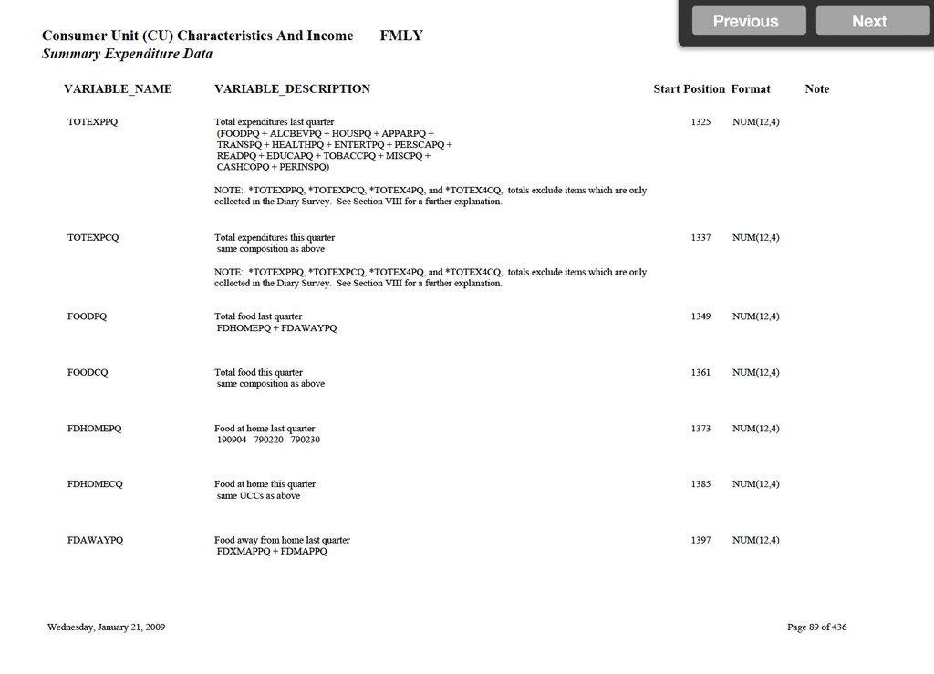

```r
formulas<-read.csv("formulas.csv")
formulas<-formulas[1:9,1:3]
pander(formulas)
```

| Category | NIPA | CES |
| --- | --- | --- |
| Food,Alcohol, Tobacco | 26,81,44 | FOODCQ+ALCBEVCQ+TOBACCQ |
| Personal Care and Clothing | 30,105,43 | APPARCQ+PERSCARCQ |
| Utilities and Housing | 42,49,96,107 | HOUSCQ-SHELTCQ-HOUSEQCQ |
| Transportation, vehicle maintenance and fuels | 36,68 | GASMOCQ+MAINPRCQ+PUBTRACQ |
| Entertainment and Recreation | 41,45,76 | ENTERTCQ-TVRDIOCQ+READPQ |
| Health | 40,60 | HEALTHCQ-HLTINCQ |
| Education | 100 | EDUCACQ |
| Finance and Insurance | 86 | PERINSCQ+HLTINCQ |
| Leftout | 46,104,106,108,111 |  |

Now, I can start building my CES and NIPA datasets. Here, I define 2 supportive functions:

```r
#Takes vector of column indexes, and column itself, and returns
#sum of the column values corresponding to indexes
sum_of_elems_in_col<-function(vector,col){
  sum<-0
  for(i in vector){
    sum<-sum+col[i]
  }
  return(sum)
}
#Function that will be used in my apply loop to build NIPA categories
nipa_breakdown<-function(nipa_col){
  total<-sum_of_elems_in_col(c(25,48),nipa_col)
  food<-sum_of_elems_in_col(c(26,81,44),nipa_col)
  clothing<-sum_of_elems_in_col(c(30,105,43),nipa_col)
  utils<-sum_of_elems_in_col(c(42,49,96,107),nipa_col)
  transp<-sum_of_elems_in_col(c(36,38),nipa_col)
  entert<-sum_of_elems_in_col(c(41,45,76),nipa_col)
  health<-sum_of_elems_in_col(c(40,60),nipa_col)
  educ<-sum_of_elems_in_col(c(100),nipa_col)
  fina<-sum_of_elems_in_col(c(86),nipa_col)
  leftout<-sum_of_elems_in_col(c(46,104,106,108,111),nipa_col)
  return(c(total,food,clothing,
           utils,transp,entert,health,educ,fina,leftout))
}
```

Building the NIPA dataset and dataset of differences:

```r
#calculating categories
nipa_by_year<-apply(nipa[,3:7],2,nipa_breakdown)
#calculating totals
col_totals<-apply(nipa_by_year[2:10,1:5],2,sum)
#calculating totals without leftouts
total_less_leftout<-apply(nipa_by_year[2:9,1:5],2,sum)
#binding the values into one dataset
#One of the columns will work as a check whether row totals are consistent
nipa_by_year<-rbind(nipa_by_year,col_totals)
nipa_by_year<-rbind(nipa_by_year,total_less_leftout)
household<-c(117.18,117.54,118.68,121.08,122.46)
#I got household data from here:
#https://www.statista.com/statistics/183635/number-of-households-in-the-us/
nipa_by_year<-rbind(nipa_by_year,household)
nipa_by_year2<-nipa_by_year
#Normalizing values using poplulating statistics
pop_normalizer<-function(nipa_column){

#divide by column13
  output<-nipa_column/nipa_column[13]*1000
  return(output)
}
#loop normalizing the entries
nipa_by_year<-apply(nipa_by_year,2,pop_normalizer)
#calculating difference dataset
calc_diff<-function(ces_row){
  #supportive function to calculate differences
  #based on simple algorithm
  output<-c()
  previous_item<-c(0)
  for(i in ces_row){
  if(previous_item==c(0)){
    previous_item<-c(i)
  } else{
    difference<-i-previous_item
    output<-c(output,difference)
    previous_item<-i
  }
  }
  return(output)
}
#loop to calculate difference
nipa_diff<-apply(nipa_by_year[1:9,1:5],1,calc_diff)
#t for TRANSPOSE
nipa_diff<-t(nipa_diff)
```

The result looks like (**When I was normalizing, I was multiplying all entries by 1000, because NIPA entries are in billions and number of households is in millions**):

```r
#adding categories names
nipa_by_year<-cbind(nipa_by_year,c("Total",as.character(formulas$Category)[1:9],"Total 2-10","Total 2-9","Household"))
pander(nipa_by_year)
```

Table continues below

|  | X2009 | X2010 |
| --- | --- | --- |
|  | 72944.1884280594 | 75345.4143270376 |
|  | 12543.0960914832 | 12871.3629402756 |
|  | 4407.74876258747 | 4595.88225285009 |
|  | 19324.1167434716 | 19590.7776076229 |
|  | 2635.2619901007 | 3059.38403947592 |
|  | 4761.90476190476 | 4897.05632125234 |
|  | 16626.557433009 | 17226.4760932449 |
|  | 1876.60010240655 | 2003.57325165901 |
|  | 6135.85936166581 | 6493.10872894334 |
|  | 4725.20908004779 | 4681.81044750723 |
| **col_totals** | 73036.3543266769 | 75419.4316828314 |
| **total_less_leftout** | 68311.1452466291 | 70737.6212353241 |
| **household** | 1000 | 1000 |

Table continues below

|  | X2011 | X2012 |
| --- | --- | --- |
|  | 78268.4529828109 | 79004.7902213413 |
|  | 13371.250421301 | 13567.8889990089 |
|  | 4803.67374452309 | 4914.93227618104 |
|  | 20007.5834175935 | 20040.4691113314 |
|  | 3697.33737782272 | 3661.2157251404 |
|  | 5071.62116616111 | 5216.38586058804 |
|  | 17847.1520053927 | 18214.403700033 |
|  | 2080.38422649141 | 2089.52758506772 |
|  | 6705.42635658915 | 6518.83052527255 |
|  | 4652.84799460735 | 4781.1364387182 |
| **col_totals** | 78237.276710482 | 79004.7902213413 |
| **total_less_leftout** | 73584.4287158746 | 74223.6537826231 |
| **household** | 1000 | 1000 |

|  | X2013 |  |
| --- | --- | --- |
|  | 80145.353584844 | Total |
|  | 13673.8526865915 | Food,Alcohol, Tobacco |
|  | 5013.0654907725 | Personal Care and Clothing |
|  | 20387.8817573085 | Utilities and Housing |
|  | 3583.21084435734 | Transportation, vehicle maintenance and fuels |
|  | 5347.86869181774 | Entertainment and Recreation |
|  | 18456.6389024988 | Health |
|  | 2120.69247101094 | Education |
|  | 6783.43949044586 | Finance and Insurance |
|  | 4753.38886166912 | Leftout |
| **col_totals** | 80120.0391964723 | Total 2-10 |
| **total_less_leftout** | 75366.6503348032 | Total 2-9 |
| **household** | 1000 | Household |

As columns 1 and 11 are almost similar, it is a good sign that my functions are working.  
Now preparing CES dataset:

```r
#Function that deals with lots of missing entries.
#Calculates average using number of nonzero entries
#as a denominator sum(vector!=0,na.rm=TRUE)
suma<-function(vector){
  if(sum(vector!=0,na.rm=TRUE)!=0){
  return(sum(vector,na.rm=TRUE)/sum(vector!=0,na.rm=TRUE))} else{
    #if there are no non-zero entries, then this is a signal that something goes wrong
    print(paste("only zero entries in a coulmn",deparse(substitute(vector)),sep=" "))
    return(0)
  }
}
#Familiar breakdown to categories
ces_file_analysis<-function(cesDf){
  food<-suma(cesDf$FOOFCQ)+suma(cesDf$ALCBEVCQ)+suma(cesDf$TOBACCQ)
  clothing<-suma(cesDf$APPARCQ)+suma(cesDf$PERSCARCQ)
  utils<-suma(cesDf$HOUSCQ)-suma(cesDf$SHELTCQ)-suma(cesDf$HOUSEQCQ)
  transp<-suma(cesDf$GASMOCQ)+suma(cesDf$MAINPRCQ)+suma(cesDf$PUBTRACQ)
  entert<-suma(cesDf$ENTERTCQ)+suma(cesDf$TVRDIOCQ)+suma(cesDf$READCQ)
  health<-suma(cesDf$HEALTHCQ)-suma(cesDf$HLTINCQ)
  educ<-suma(cesDf$EDUCACQ)
  fina<-suma(cesDf$PERINSCQ)+suma(cesDf$HLTINCQ)
  total<-food+clothing+utils+transp+entert+health+educ+fina
  #taking average
  return(c(total,food,clothing,
           utils,transp,entert,health,educ,fina))
}
#Loop, that calculates averages for each quarter and adds
#them up to make year average
ces_maker<-function(){
  #just a placeholder which will be deleted later
  output<-c(0,0,0,0,0,0,0,0,0)
  for(i in c("07","08","09","10","11","12","13")){
    #loop over years. years 07, 08 are later deleted
    #I know there is a problem with reusability of my code:(
    year_output<-c(0,0,0,0,0,0,0,0,0)
    #the quarterly values will be added to the zeros
    #to make annual values
    for(z in c("1x","2","3","4")){
      #loop over quarterly files
      filename<-paste("d",i,z,sep="")
      file<-get(filename)
      year_output<-year_output+ces_file_analysis(file)
    }
    output<-cbind(output,year_output)
  }
  return(output)
}
ces_output<-ces_maker()
```

[output not shown]

[output cut: 153 more lines]

```r
ces_output<-ces_output[,4:8]
#calculate differences with previously defined function calc_diff
ces_diff<-apply(ces_output[,1:5],1,calc_diff)
ces_diff<-t(ces_diff)
ces_output<-cbind(ces_output,c("Total",as.character(formulas$Category)[1:8]))
```

CES output looks like:

```r
#adding categories names
colnames(ces_output)<-c(2009,2010,2011,2012,2013,00000)
pander(ces_output)
```

Table continues below

| 2009 | 2010 | 2011 | 2012 |
| --- | --- | --- | --- |
| 18399.4593013507 | 19271.0175740392 | 18505.6216254476 | 19983.3140691822 |
| 511.206578089024 | 491.373486941049 | 508.151344431945 | 518.064862673538 |
| 1009.83596900121 | 1025.96053207611 | 941.699406799469 | 1042.17828091354 |
| 1586.28171542993 | 1581.1450075622 | 1573.82214779742 | 1530.23890598812 |
| 2938.47308965084 | 3060.45931783665 | 3220.8317587288 | 3481.86044477562 |
| 2229.17749844298 | 2086.19954974963 | 2098.33235081968 | 2241.6054680285 |
| 1779.16262455461 | 1784.7069671567 | 1875.74803161352 | 1994.67106403543 |
| 4568.01747740848 | 5572.628671411 | 4602.3941836211 | 5386.45426821964 |
| 3777.30434877359 | 3668.54404130585 | 3684.64240163562 | 3788.24077454786 |

| 2013 | 0 |
| --- | --- |
| 18960.2926329285 | Total |
| 549.577598740749 | Food,Alcohol, Tobacco |
| 868.182131341179 | Personal Care and Clothing |
| 1493.79620632514 | Utilities and Housing |
| 3339.89110704809 | Transportation, vehicle maintenance and fuels |
| 2245.83098522065 | Entertainment and Recreation |
| 1991.37146029109 | Health |
| 4774.26583410057 | Education |
| 3697.37730986099 | Finance and Insurance |

Finally doing the plots (ces is solid):

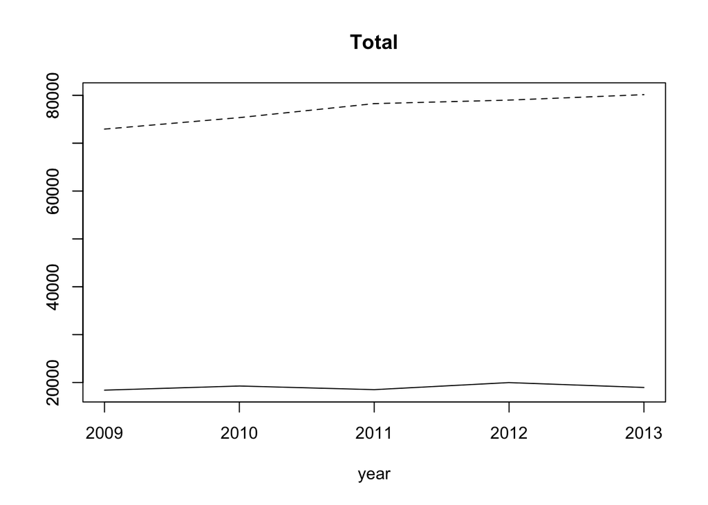

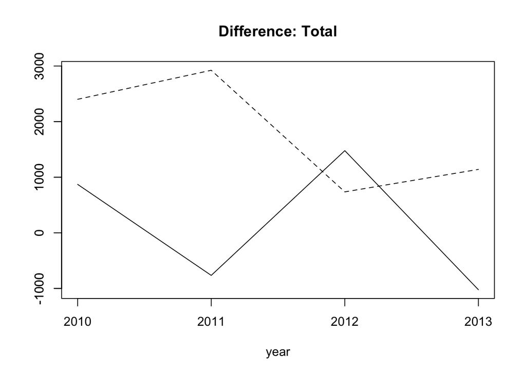

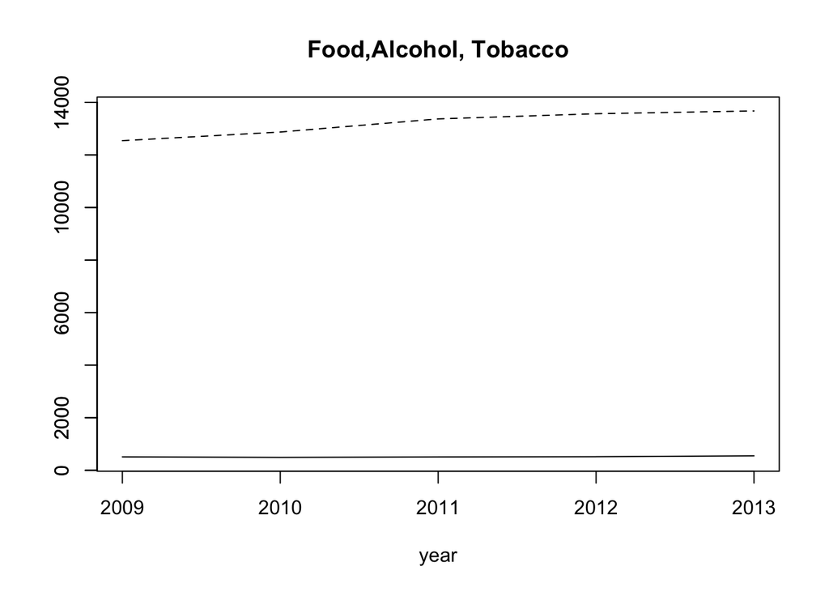

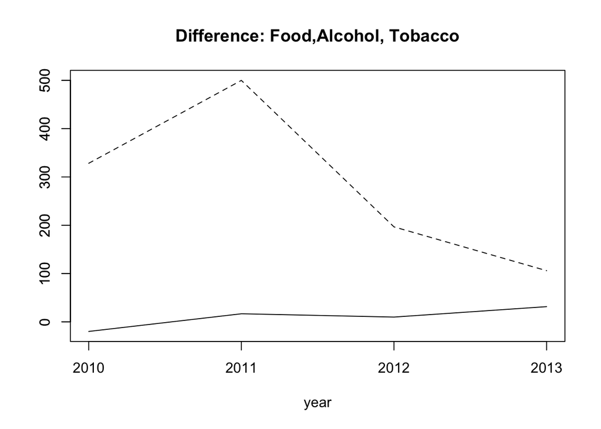

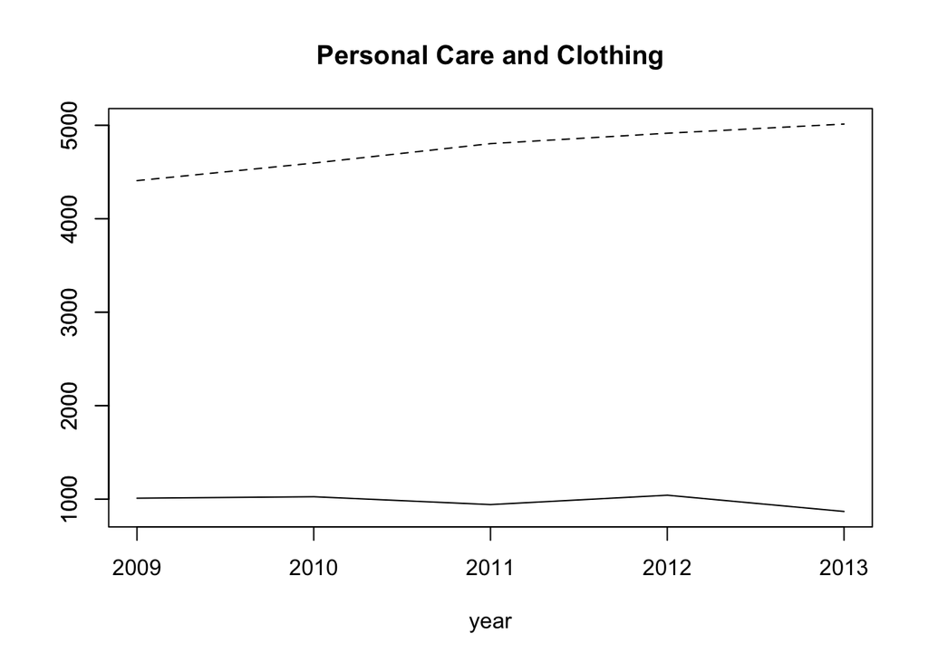

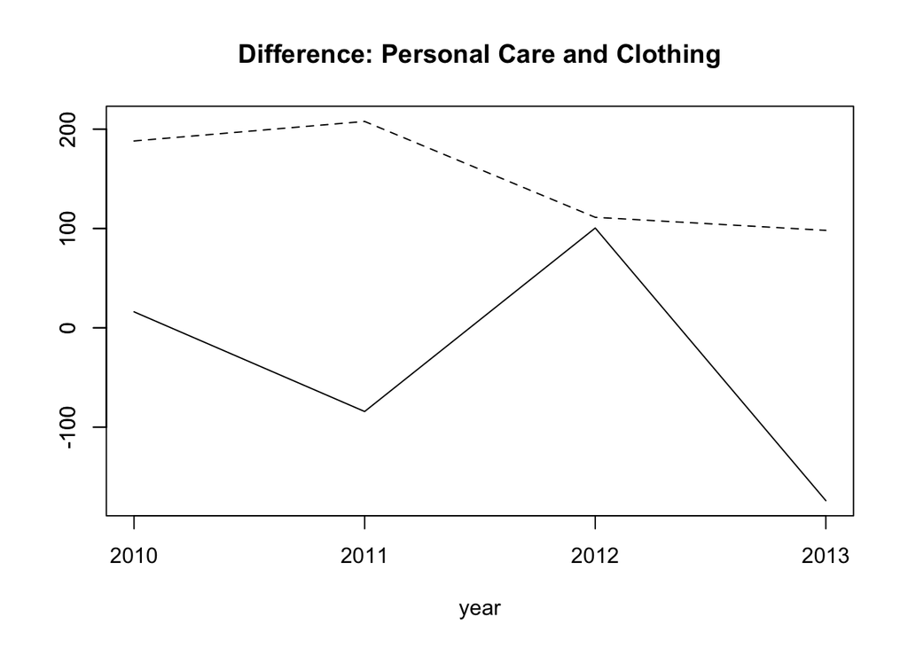

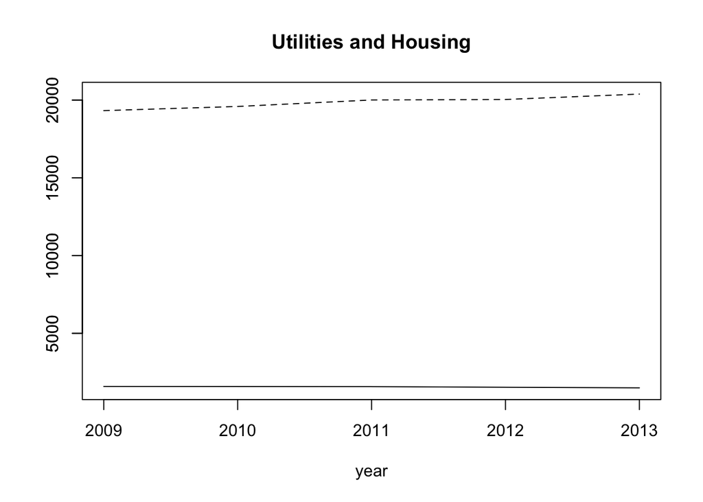

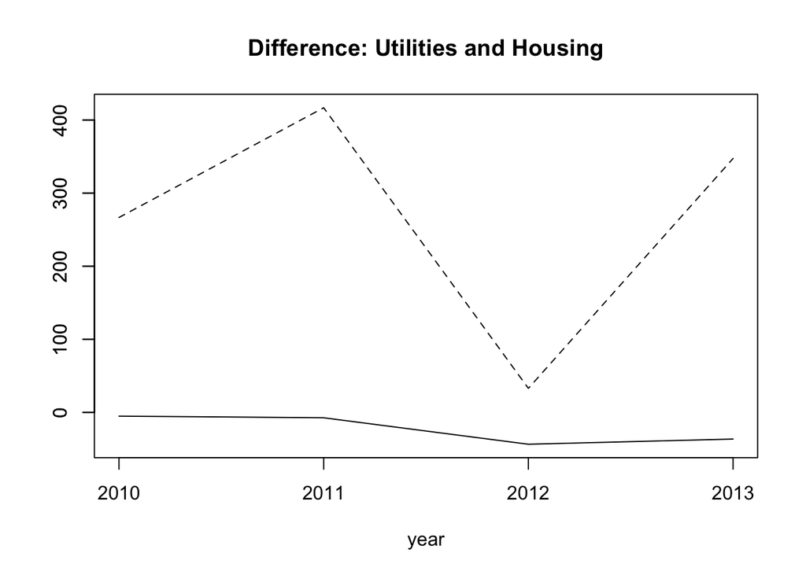

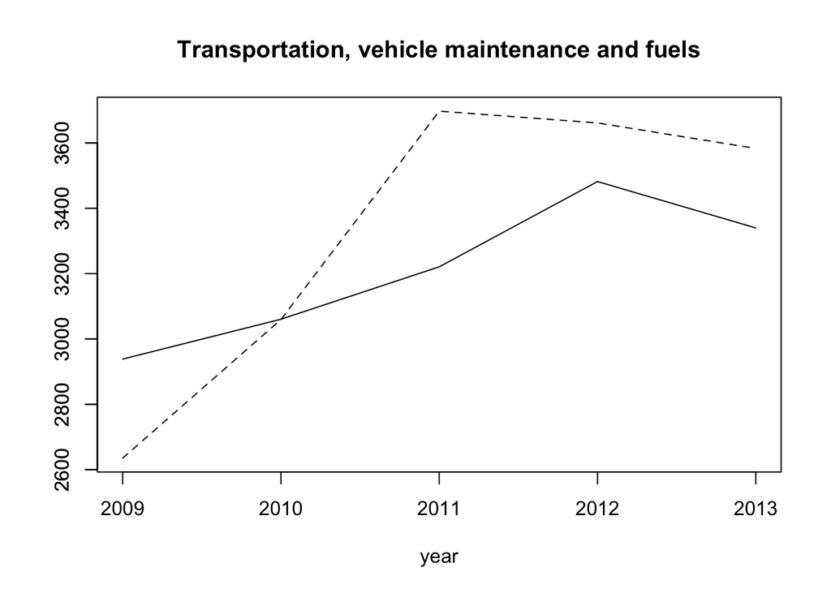

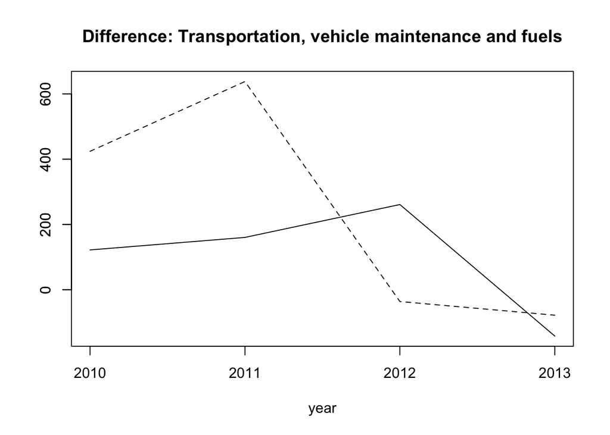

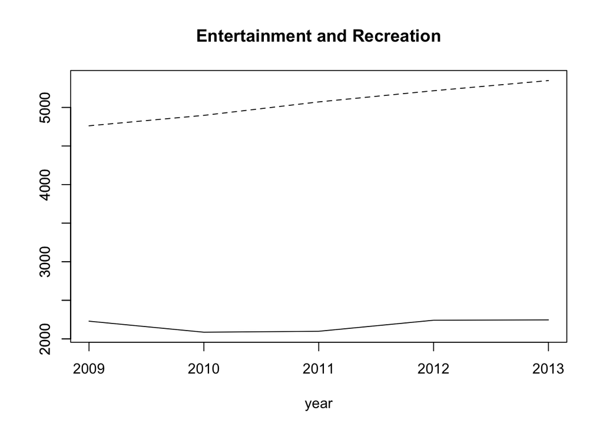

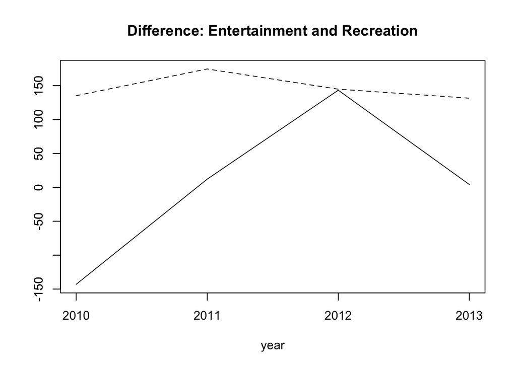

[6 more figures not shown]

```r
for(i in 1:9){
  row_ces<-ces_output[i,]
  row_nipa<-nipa_by_year[i,]
  row_ces_diff<-ces_diff[i,]
  row_nipa_diff<-nipa_diff[i,]
  row_ces_plot<-row_ces[1:5]
  names(row_ces_plot)<-c(2009,2010,2011,2012,2013)
  row_nipa_plot<-row_nipa[1:5]
  names(row_nipa_plot)<-c(2009,2010,2011,2012,2013)
  row_ces_plot_diff<-row_ces_diff[1:4]
  names(row_ces_plot_diff)<-c(2010,2011,2012,2013)
  row_nipa_plot_diff<-row_nipa_diff[1:4]
  names(row_nipa_plot_diff)<-c(2010,2011,2012,2013)
  ts.plot(as.ts(row_ces_plot),as.ts(row_nipa_plot),main=row_nipa[6],xlab="year",lty=c(1,2),gpars=list(xaxt="n"))
  axis(2)
  axis(1,labels=c(2009,2010,2011,2012,2013),at=c(1,2,3,4,5))
  ts.plot(as.ts(row_ces_plot_diff),as.ts(row_nipa_plot_diff),main=paste("Difference:",row_nipa[6],sep=" "),xlab="year",lty=c(1,2),gpars=list(xaxt="n"))
  axis(2)
  axis(1,labels=c(2010,2011,2012,2013),at=c(1,2,3,4))
  #plot()
}
```

```r
print(mean(d071x$TOTEXPCQ))
```

```
## [1] 4325.687
```

```r
#quarterly and not ajusted for zeros
print(suma(d071x$TOTEXPCQ))
```

```
## [1] 6568.636
```

```r
#quarterly adjusted for zeros
setwd("/Users/andriylevitskyy/Desktop/MA/Qu Macro/Problem Set1/dataweb")
library(foreign)
filecex<-read.dta("cex_a.dta")
summary(filecex)
```

```
##        id              rururb         intnum        intqua
##  Min.   :      2   Min.   :1.00   Min.   :2.0   Min.   :1.000
##  1st Qu.:5015353   1st Qu.:1.00   1st Qu.:2.0   1st Qu.:1.000
##  Median :5065192   Median :1.00   Median :3.0   Median :2.000
##  Mean   :4290235   Mean   :1.09   Mean   :3.5   Mean   :2.496
##  3rd Qu.:5124165   3rd Qu.:1.00   3rd Qu.:5.0   3rd Qu.:4.000
##  Max.   :5181763   Max.   :2.00   Max.   :5.0   Max.   :4.000
##
##       quac            intyea           intmon           nmo15
##  Min.   :  1.00   Min.   : 80.00   Min.   : 1.000   Min.   : 0.0000
##  1st Qu.: 32.00   1st Qu.: 87.00   1st Qu.: 3.000   1st Qu.: 1.0000
##  Median : 62.00   Median : 95.00   Median : 6.000   Median : 1.0000
##  Mean   : 60.12   Mean   : 94.41   Mean   : 6.497   Mean   : 0.8992
##  3rd Qu.: 89.00   3rd Qu.:102.00   3rd Qu.:10.000   3rd Qu.: 1.0000
##  Max.   :109.00   Max.   :107.00   Max.   :12.000   Max.   :10.0000
##
##      nwo15           nmu15            nwu15             nbab
##  Min.   :0.000   Min.   :0.0000   Min.   :0.0000   Min.   :0.00000
##  1st Qu.:1.000   1st Qu.:0.0000   1st Qu.:0.0000   1st Qu.:0.00000
##  Median :1.000   Median :0.0000   Median :0.0000   Median :0.00000
##  Mean   :1.009   Mean   :0.2812   Mean   :0.2669   Mean   :0.07715
##  3rd Qu.:1.000   3rd Qu.:0.0000   3rd Qu.:0.0000   3rd Qu.:0.00000
##  Max.   :8.000   Max.   :8.0000   Max.   :8.0000   Max.   :4.00000
##
##      refage          refsex         refrace          refedu
##  Min.   :14.00   Min.   :1.000   Min.   :0.000   Min.   :0.000
##  1st Qu.:33.00   1st Qu.:1.000   1st Qu.:1.000   1st Qu.:2.000
##  Median :44.00   Median :1.000   Median :1.000   Median :3.000
##  Mean   :46.82   Mean   :1.326   Mean   :1.235   Mean   :2.648
##  3rd Qu.:58.00   3rd Qu.:2.000   3rd Qu.:1.000   3rd Qu.:3.000
##  Max.   :94.00   Max.   :2.000   Max.   :6.000   Max.   :5.000
##
##      refwks         refwagen            refth          refhpw
##  Min.   : 0.00   Min.   :    1.55   Min.   :   0   Min.   : 0.00
##  1st Qu.: 1.00   1st Qu.:    7.40   1st Qu.:   2   1st Qu.: 1.00
##  Median :52.00   Median :   12.02   Median :2080   Median :40.00
##  Mean   :35.25   Mean   :   19.17   Mean   :1513   Mean   :31.68
##  3rd Qu.:52.00   3rd Qu.:   19.23   3rd Qu.:2080   3rd Qu.:44.00
##  Max.   :52.00   Max.   :75000.00   Max.   :5148   Max.   :99.00
##                  NA's   :120988
```

[output cut: 225 more lines]

```
##  Min.   :-129590   Min.   : -34900   Min.   :-115927   Min.   : -30022
##  1st Qu.:  13538   1st Qu.:  14200   1st Qu.:   9982   1st Qu.:  10373
##  Median :  26755   Median :  29000   Median :  19438   Median :  20936
##  Mean   :  37542   Mean   :  40526   Mean   :  25172   Mean   :  27310
##  3rd Qu.:  48700   3rd Qu.:  52750   3rd Qu.:  33373   3rd Qu.:  36572
##  Max.   :9723261   Max.   :9728927   Max.   :5357279   Max.   :5360400
##
##    earningsn          earnings          refwage            cpidefla
##  Min.   : -20000   Min.   : -20007   Min.   :    1.29   Min.   :0.7341
##  1st Qu.:   3200   1st Qu.:   2454   1st Qu.:    5.43   1st Qu.:1.1281
##  Median :  23966   Median :  17241   Median :    8.55   Median :1.4967
##  Mean   :  33503   Mean   :  22534   Mean   :   12.64   Mean   :1.4590
##  3rd Qu.:  48000   3rd Qu.:  33383   3rd Qu.:   12.98   3rd Qu.:1.7725
##  Max.   :6459284   Max.   :3558908   Max.   :40892.43   Max.   :2.0201
##                                      NA's   :120988
```

```r
#Have a good look at the mean of nondur variables
```

The last output is the sample from “Unequal We stand”. There is no way according to the result that expenditure is as high as NIPAs figures.  
Conclusion: Who are the people in NIPA who consume 70k worth of nondurable goods and services? Bill Gates? Donald Trump? I guess it is better chose cateories from NIPA to fit CES then try to choose categories from CES to track NIPA. It is very likey that NIPA includes some things which not appear in CES.